# HW6

Conor Dickson

2/19/2020

1. Set up a new .Rmd file for this exercise. Copy and paste the code below into different code chunks, and then read the text and run the code chunks one at a time to see what they do. You probably won’t understand everything in the code, but this is a good start for seeing some realistic uses of ggplot. We will cover most of these details in the next few weeks.

```r
library(ggplot2) # for graphics
library(MASS) # for maximum likelihood estimation

# quick and dirty, a truncated normal distribution to work on the solution set

z <- rnorm(n=3000,mean=0.2)
z <- data.frame(1:3000,z)
names(z) <- list("ID","myVar")
z <- z[z$myVar>0,]
print(z)
```

```
##        ID       myVar
## 1       1 0.967126859
## 3       3 0.478935966
## 4       4 1.081865771
## 5       5 0.276025386
## 6       6 1.592246871
## 7       7 0.416941229
## 8       8 0.498121570
## 11     11 0.755162769
## 12     12 0.443087023
## 13     13 0.125149199
## 16     16 0.463650970
## 18     18 1.048078503
## 20     20 1.172208603
## 22     22 0.417513183
```

[output cut: 1775 more lines]

```r
str(z)
```

```
## 'data.frame':    1789 obs. of  2 variables:
##  $ ID   : int  1 3 4 5 6 7 8 11 12 13 ...
##  $ myVar: num  0.967 0.479 1.082 0.276 1.592 ...
```

```r
summary(z$myVar)
```

```
##     Min.  1st Qu.   Median     Mean  3rd Qu.     Max.
## 0.003285 0.359848 0.739654 0.857617 1.268756 3.433862
```

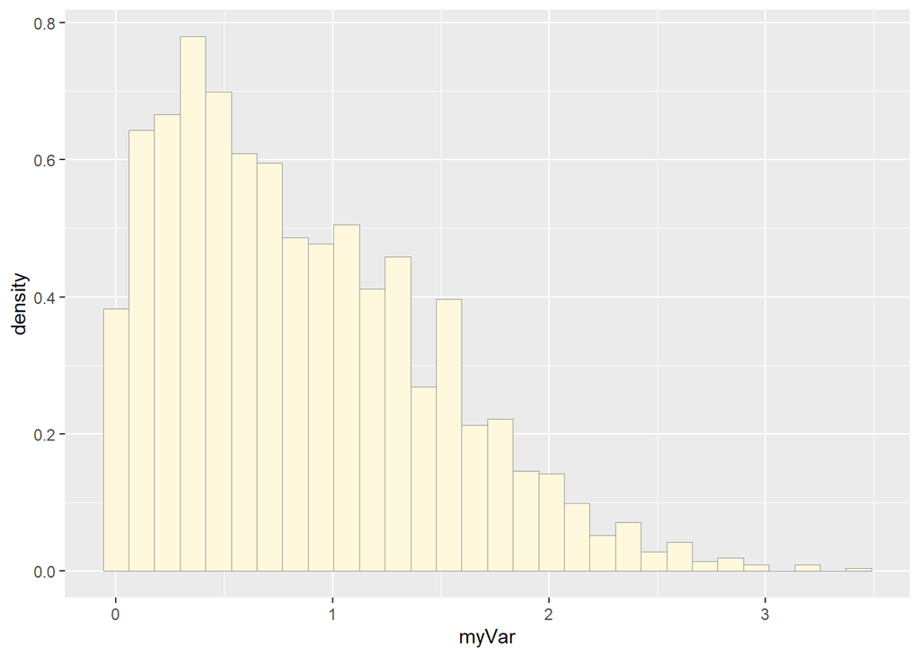

```r
# Plot histogram of Data

p1 <- ggplot(data=z, aes(x=myVar, y=..density..))  +
  geom_histogram(color="grey60",fill="cornsilk",size=0.2) # aes() defines dimension (x & y) names
print(p1)
```

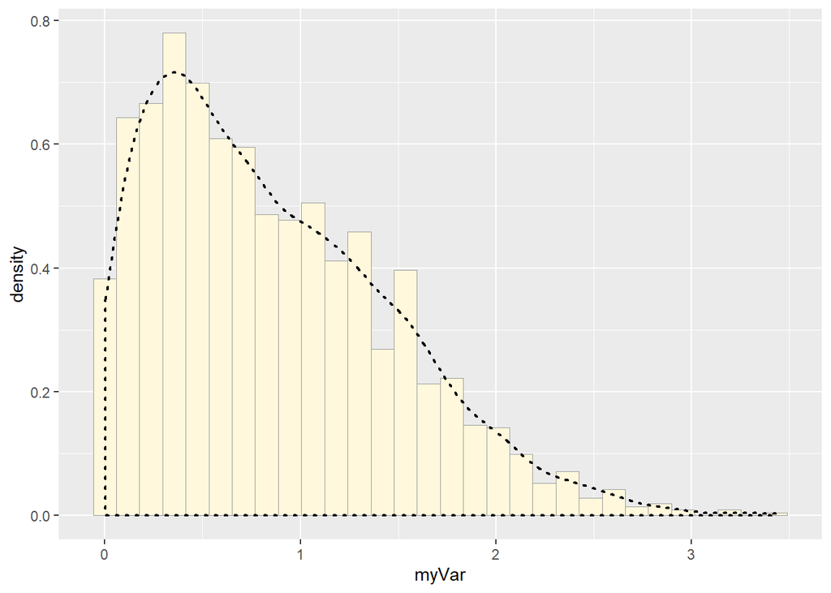

```r
# Add empirical density curve

p1 <-  p1 +  geom_density(linetype="dotted",size=0.75)
print(p1)
```

```r
# Get maximum likelihood parameters

normPars <- fitdistr(z$myVar,"normal")
print(normPars)
```

```
##       mean          sd
##   0.85761725   0.61487455
##  (0.01453722) (0.01027937)
```

```r
str(normPars)
```

```
## List of 5
##  $ estimate: Named num [1:2] 0.858 0.615
##   ..- attr(*, "names")= chr [1:2] "mean" "sd"
##  $ sd      : Named num [1:2] 0.0145 0.0103
##   ..- attr(*, "names")= chr [1:2] "mean" "sd"
##  $ vcov    : num [1:2, 1:2] 0.000211 0 0 0.000106
##   ..- attr(*, "dimnames")=List of 2
##   .. ..$ : chr [1:2] "mean" "sd"
##   .. ..$ : chr [1:2] "mean" "sd"
##  $ n       : int 1789
##  $ loglik  : num -1668
##  - attr(*, "class")= chr "fitdistr"
```

```r
normPars$estimate["mean"] # note structure of getting a named attribute
```

```
##      mean
## 0.8576173
```

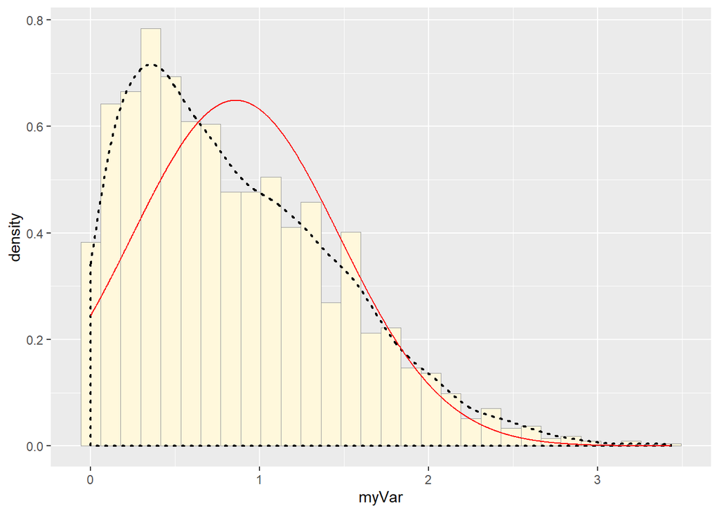

```r
# Plot normal probability desnity

meanML <- normPars$estimate["mean"]
sdML <- normPars$estimate["sd"]

xval <- seq(0,max(z$myVar),len=length(z$myVar))

 stat <- stat_function(aes(x = xval, y = ..y..), fun = dnorm, colour="red", n = length(z$myVar), args = list(mean = meanML, sd = sdML))
 p1 + stat
```

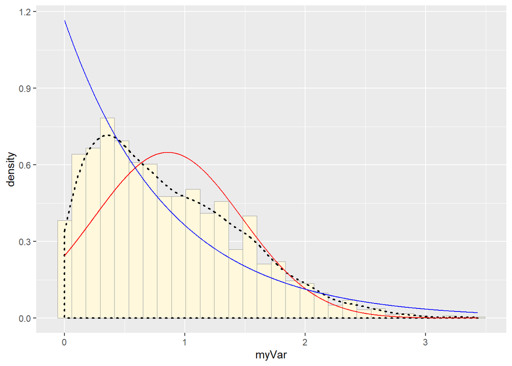

```r
# Plot exponential probability density

 expoPars <- fitdistr(z$myVar,"exponential")
rateML <- expoPars$estimate["rate"]

stat2 <- stat_function(aes(x = xval, y = ..y..), fun = dexp, colour="blue", n = length(z$myVar), args = list(rate=rateML))
 p1 + stat + stat2
```

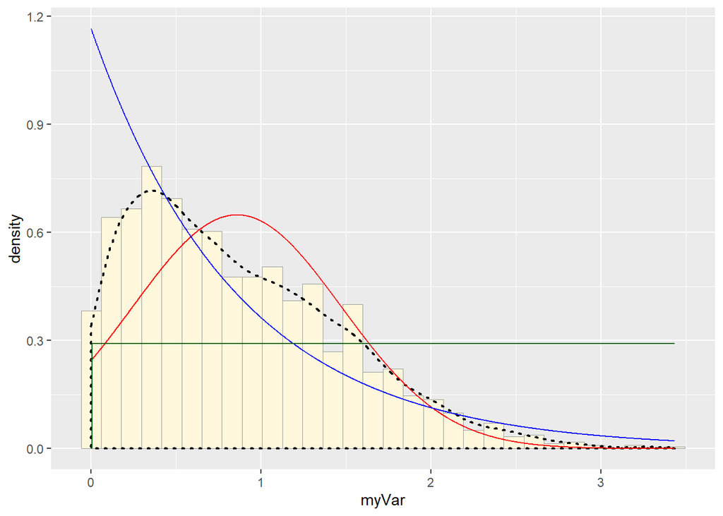

```r
# Plot uniform probability density

 stat3 <- stat_function(aes(x = xval, y = ..y..), fun = dunif, colour="darkgreen", n = length(z$myVar), args = list(min=min(z$myVar), max=max(z$myVar)))
 p1 + stat + stat2 + stat3
```

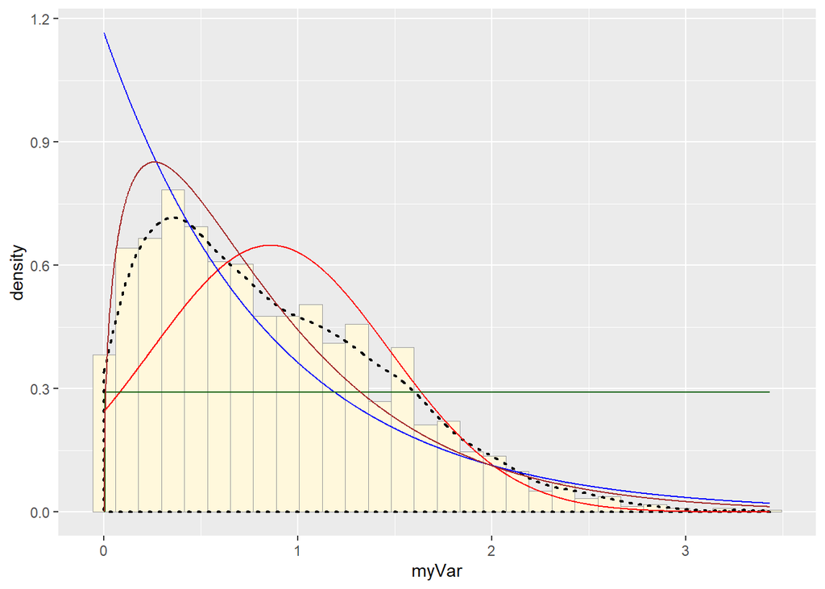

```r
# Plot gamma probability density

gammaPars <- fitdistr(z$myVar,"gamma")
shapeML <- gammaPars$estimate["shape"]
rateML <- gammaPars$estimate["rate"]

stat4 <- stat_function(aes(x = xval, y = ..y..), fun = dgamma, colour="brown", n = length(z$myVar), args = list(shape=shapeML, rate=rateML))
 p1 + stat + stat2 + stat3 + stat4
```

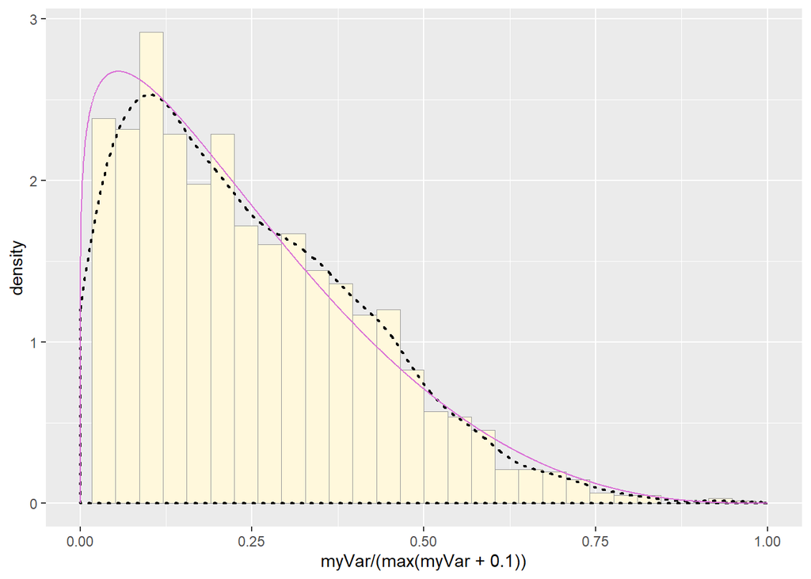

```r
# Plot beta probability density

pSpecial <- ggplot(data=z, aes(x=myVar/(max(myVar + 0.1)), y=..density..)) +
  geom_histogram(color="grey60",fill="cornsilk",size=0.2) +
  xlim(c(0,1)) +
  geom_density(size=0.75,linetype="dotted")

betaPars <- fitdistr(x=z$myVar/max(z$myVar + 0.1),start=list(shape1=1,shape2=2),"beta")
shape1ML <- betaPars$estimate["shape1"]
shape2ML <- betaPars$estimate["shape2"]

statSpecial <- stat_function(aes(x = xval, y = ..y..), fun = dbeta, colour="orchid", n = length(z$myVar), args = list(shape1=shape1ML,shape2=shape2ML))
pSpecial + statSpecial
```

2. Once the code is in and runs, try running this analysis on your own data (or data from your lab). Find a vector of data (of any size), set it up in a .csv file, and read the data into a data frame with this code chunk:

```r
z <- read.table("PracticeData.csv",header=TRUE,sep=",", stringsAsFactors=FALSE)
z <- z[z$Power>0,]
print(z$Power)
```

```
##   [1]  84.93706  84.53002  86.69154  91.60519  96.02920  99.53120 102.29347
##   [8] 104.36460 105.79340 106.61864 106.88933 106.74191 106.03153 104.77569
##  [15] 102.92268 100.37357  97.09402  92.83144  87.26989  81.47430  79.76148
##  [22]  79.73010  79.39286  79.19903  78.94804  78.60743  78.45054  79.51937
##  [29]  82.73196  86.83718  90.33816  93.22574  95.34712  96.83069  97.73381
##  [36]  98.10755  98.04728  97.42044  96.21540  94.41300  91.95579  88.85559
##  [43]  84.80786  80.05958  76.42028  75.47770  75.35622  75.20167  75.18703
##  [50]  74.96624  74.64889  74.70687  74.96127  75.57883  76.71875  78.82167
##  [57]  81.25458  83.32399  84.86141  85.82119  86.23752  83.41944  83.59851
##  [64]  83.41933  83.07878  82.75495  81.90732  82.98844  86.75252  92.49714
##  [71]  97.02737  99.89053 103.25627 105.31634 106.71607 107.51929 107.14363
##  [78] 107.63818 106.94578 105.62224 103.63578 100.30832  97.62276  93.23062
##  [85]  87.41256  81.40569  78.29333  78.57197  78.43945  78.16439  77.87312
##  [92]  76.86647  77.62560  77.74463  77.70944  77.37790  76.47187  77.60689
##  [99]  79.32666  83.19054  87.69598  90.55166  94.18091  96.36272  97.84843
```

[output cut: 55 more lines]

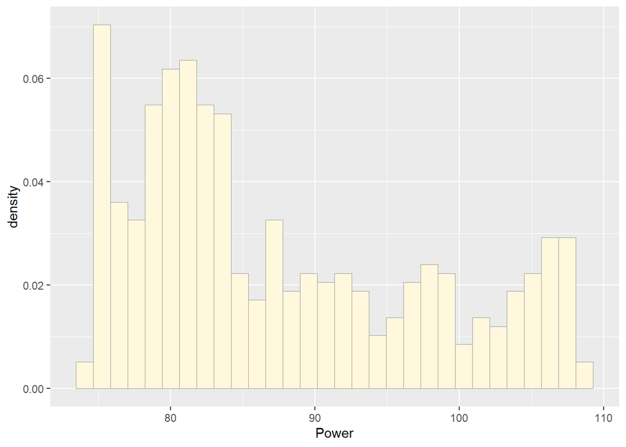

```r
names(z)[1] <- "Hz"

# Plot Histogram of data
p1 <- ggplot(data=z, aes(x=Power,y=..density..)) +
  geom_histogram(color="grey60",fill="cornsilk",size=0.2)
print(p1)
```

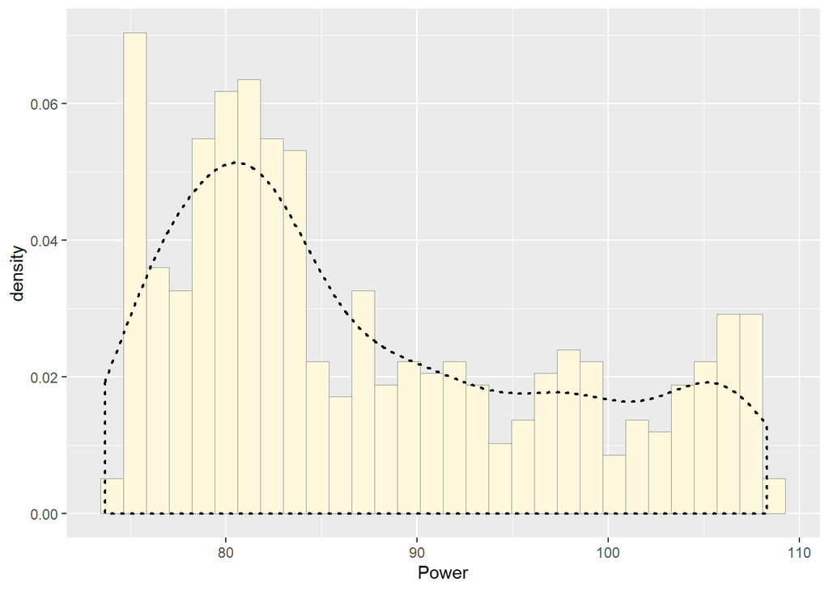

```r
#Add empirical density curve
p1 <-  p1 +  geom_density(linetype="dotted",size=0.75)
print(p1)
```

```r
# Maximum likelihood parameters
normPars <- fitdistr(z$Power,"normal")
print(normPars)
```

```
##       mean          sd
##   87.5855868   10.0370901
##  ( 0.4543577) ( 0.3212794)
```

```r
str(normPars)
```

```
## List of 5
##  $ estimate: Named num [1:2] 87.6 10
##   ..- attr(*, "names")= chr [1:2] "mean" "sd"
##  $ sd      : Named num [1:2] 0.454 0.321
##   ..- attr(*, "names")= chr [1:2] "mean" "sd"
##  $ vcov    : num [1:2, 1:2] 0.206 0 0 0.103
##   ..- attr(*, "dimnames")=List of 2
##   .. ..$ : chr [1:2] "mean" "sd"
##   .. ..$ : chr [1:2] "mean" "sd"
##  $ n       : int 488
##  $ loglik  : num -1818
##  - attr(*, "class")= chr "fitdistr"
```

```r
normPars$estimate["mean"] # note structure of getting a named attribute
```

```
##     mean
## 87.58559
```

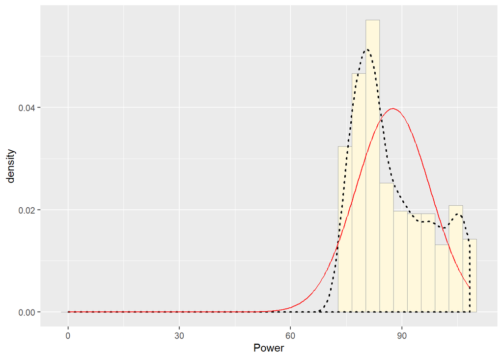

```r
# Plot normal probability density
meanML <- normPars$estimate["mean"]
sdML <- normPars$estimate["sd"]

xval <- seq(0,max(z$Power),len=length(z$Power))

 stat <- stat_function(aes(x = xval, y = ..y..), fun = dnorm, colour="red", n = length(z$Power), args = list(mean = meanML, sd = sdML))
 p1 + stat # No negative values result in a biased curve
```

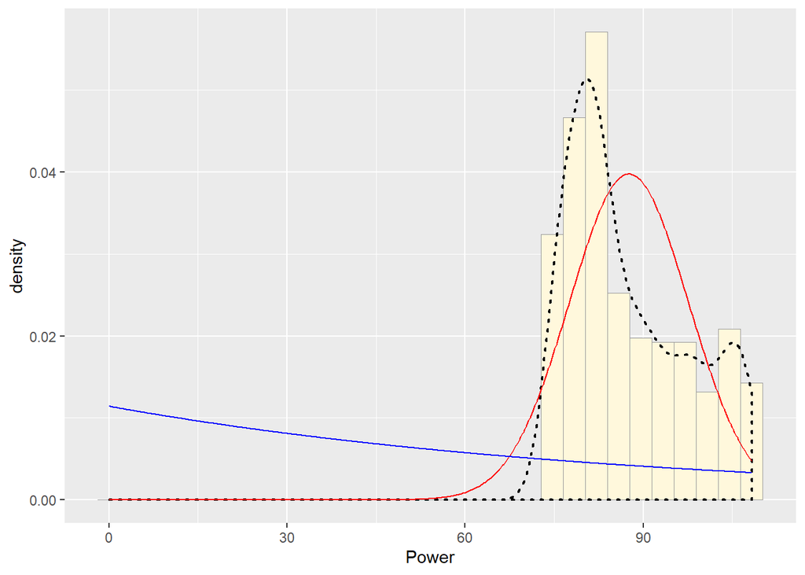

```r
# Plot exponential probability density
expoPars <- fitdistr(z$Power,"exponential")
rateML <- expoPars$estimate["rate"]

stat2 <- stat_function(aes(x = xval, y = ..y..), fun = dexp, colour="blue", n = length(z$Power), args = list(rate=rateML))
 p1 + stat + stat2
```